# Math311_HW5

Jackson Evans

5/18/2021

9.14) a)

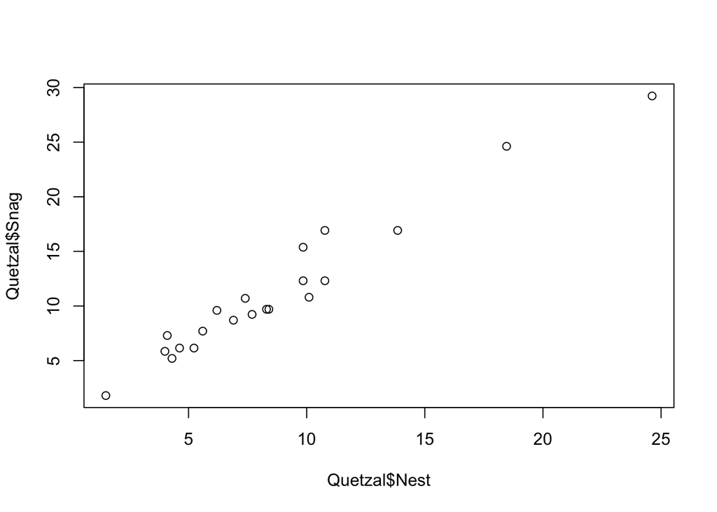

```r
library(resampledata)
plot(Quetzal$Nest,
     Quetzal$Snag)
```

The relationship looks quite linear, in the positive direction.

Assumptions: The variables are linearly related. This is visually evident. The residuals are normally distributed (o, sigma^2).

```r
quetzal_model<-lm(Snag ~ Nest, data = Quetzal)
quetzal_model
```

```
##
## Call:
## lm(formula = Snag ~ Nest, data = Quetzal)
##
## Coefficients:
## (Intercept)         Nest
##      0.8036       1.2021
```

Our linear model suggests a least squares regression line with a slope of 1.2021. So as the Nest height increases by 1 unit, the Snag height increases by 1.2 units.

3. Using our linear model in part b,

```r
eight_estimate <- (8-0.8036)/1.2021
eight_estimate
```

```
## [1] 5.986524
```

The predicted nest height is 5.986524 units.

```r
summary(lm(Snag ~ Nest, data = Quetzal))
```

```
##
## Call:
## lm(formula = Snag ~ Nest, data = Quetzal)
##
## Residuals:
##     Min      1Q  Median      3Q     Max
## -2.1448 -0.9405 -0.3981  1.0009  3.1698
##
## Coefficients:
##             Estimate Std. Error t value Pr(>|t|)
## (Intercept)  0.80357    0.61916   1.298     0.21
## Nest         1.20210    0.06134  19.598 4.61e-14 ***
## ---
## Signif. codes:  0 '***' 0.001 '**' 0.01 '*' 0.05 '.' 0.1 ' ' 1
##
## Residual standard error: 1.443 on 19 degrees of freedom
## Multiple R-squared:  0.9529, Adjusted R-squared:  0.9504
## F-statistic: 384.1 on 1 and 19 DF,  p-value: 4.606e-14
```

The r squared is 0.9529, meaning that 95.29% of the variability is taken into account in the model. 95.29% of variation in the data is explained by the model we built.

9.28) a)Find the correlation between literacy rates and births. Bootstrap a 95% confidence interval.

```r
N<-10^3
cor_boot<-numeric(N)
n<-94
set.seed(781)
for(i in 1:N){
  index<-sample(n, replace=TRUE)
  illiteracy_boot<-Illiteracy[index,]
  cor_boot[i]<-cor(illiteracy_boot$Illit, illiteracy_boot$Births)
}
quantile(cor_boot,c(0.025, .975))
```

```
##      2.5%     97.5%
## 0.6737494 0.8424229
```

b)Do permutation test for independence. Permute Illit and leave Births fixed.

```r
N<-9999
n<-nrow(Illiteracy)
result<-numeric(N)
observed<-cor(Illiteracy$Illit, Illiteracy$Births)
set.seed((555))
for(i in 1:N){
  index<-sample(n, replace=FALSE)
  Illit_permuted<-Illiteracy$Illit[index]
  result[i]<-cor(Illit_permuted, Illiteracy$Births)
}
(sum(observed<= result) +1)/(N+1) #p-value
```

```
## [1] 1e-04
```

```r
observed
```

```
## [1] 0.768663
```

The p-value is quite small, and significant. Therefore we can conclude that random chance alone probably did not produce an observed correlation of .77. Therefore we conclude that illiteracy rates and births are not independent.

9.40) a) Logistic equation for log-odds of male passenger surviving against age

```r
logistic_model <- glm(Survived ~ Age, data = Titanic,
                      family = "binomial")
summary(logistic_model)
```

```
##
## Call:
## glm(formula = Survived ~ Age, family = "binomial", data = Titanic)
##
## Deviance Residuals:
##     Min       1Q   Median       3Q      Max
## -0.9096  -0.7158  -0.6472  -0.4961   2.2960
##
## Coefficients:
##              Estimate Std. Error z value Pr(>|z|)
## (Intercept) -0.660761   0.224807  -2.939  0.00329 **
## Age         -0.023760   0.007276  -3.266  0.00109 **
## ---
## Signif. codes:  0 '***' 0.001 '**' 0.01 '*' 0.05 '.' 0.1 ' ' 1
##
## (Dispersion parameter for binomial family taken to be 1)
##
##     Null deviance: 667.85  on 657  degrees of freedom
## Residual deviance: 656.56  on 656  degrees of freedom
## AIC: 660.56
##
## Number of Fisher Scoring iterations: 4
```

2. 30 year old vs 40 year old.

```r
logistic_model <- glm(Survived ~ Age, data = Titanic,
                      family = "binomial")
a<-logistic_model$coefficients[[1]] #intercept
b<-logistic_model$coefficients[[2]] #slope
x<-c(30,40)
exp(a + b*x)/(1+exp(a + b*x)) #probability
```

```
## [1] 0.2020456 0.1664280
```

The probability of survival for a 30 year old is .2, whereas the probability of survival for a 40 year old is .17.

3. bootstrap a 95% CI

```r
ans<-NULL
n<-nrow(Titanic)
set.seed(310)
for(i in 1:10000){
  index <- sample(n, replace = TRUE)
  new<-Titanic[index,]
  new_model<-glm(Survived ~ Age, data = new,
                 family="binomial")
  ans[i]<-new_model$coefficients[[2]]
}

quantile(ans,c(0.025, .975))
```

```
##         2.5%        97.5%
## -0.040287046 -0.008524567
```

4. Estimate 69 year old male surviving. Do a 95% bootstrap interval for probability.

```r
logistic_model <- glm(Survived ~ Age, data = Titanic,
                      family = "binomial")
a<-logistic_model$coefficients[[1]] #intercept
b<-logistic_model$coefficients[[2]] #slope
x<-69
exp(a + b*x)/(1+exp(a + b*x)) #probability of survival
```

```
## [1] 0.09110687
```

```r
#bootstrapping

N<-10^3
n<-nrow(Titanic)
alpha_boot<-numeric(N)
beta_boot<-numeric(N)
pPred_boot<-numeric(N)
set.seed(312)
for(i in 1:N){
  index<-sample(n, replace=TRUE)
  survival_boot<-Titanic[index,]
  fit_boot<-glm(Survived ~ Age, data=survival_boot,
                family='binomial')
  alpha_boot[i]<-coef(fit_boot)[1]
  beta_boot[i]<-coef(fit_boot)[2]
  pPred_boot[i]<-plogis(alpha_boot[i] + 69*beta_boot[i])
}
quantile(pPred_boot,c(0.25,.975))
```

```
##        25%      97.5%
## 0.07178457 0.15784377
```